# Tri rapide

*Hoare, C. A. R. (1961). "Algorithm 64: Quicksort". Comm. ACM. 4 (7): 321*

## Principe

Le tri rapide est un algorithme récursif consistant à

- choisir une valeur pivot parmi les éléments du tableau
- partitionner le tableau en: [ <= pivot ] pivot [ >= pivot ]
- appeler récursivement le tri rapide sur les 2 partitions

## Partition

#### Entrée:

Le sous tableau `T[premier:dernier]` dont le dernier élément sert de pivot

#### Sortie:

L'indice `i` du pivot dans le tableau partitionné tel que

- `T[premier:i]` contient les éléments `<= pivot`
- `T[i]` contient le pivot
- `T[i+1:dernier]` contient les éléments `>= pivot`

#### Algorithme: deux parcours simultanés de tableau

- croissant (`i`), s'arrête quand `T[i] >= pivot`
- décroissant (`j`), s'arrête quand `T[j] <= pivot`

à chaque arrêt de `i` et `j`, on permute `T[i]` et `T[j]`, puis on continue

### Parcours croissant (i)

```python
def i_suivant(T,i,pivot):
    while i < pivot and T[i] < T[pivot]:
        i += 1
    return i
```

```python
T = [ 7, 6, 2, 1, 3, 5, 8, 4 ]; pivot = len(T)-1

i = i_suivant(T,0,pivot)
print("T [",i,"] =",T[i],">=",T[pivot])
```

```
T [ 0 ] = 7 >= 4
```

```python
i = i_suivant(T,i+1,pivot)
print("T [",i,"] =",T[i],">=",T[pivot])
```

```
T [ 1 ] = 6 >= 4
```

```python
i = i_suivant(T,i+1,pivot)
print("T [",i,"] =",T[i],">=",T[pivot])
```

```
T [ 5 ] = 5 >= 4
```

### Parcours décroissant (j)

```python
def j_precedent(T,j,pivot):
    while j >= 0 and T[j] > T[pivot]:
        j -= 1
    return j
```

```python
T = [ 7, 6, 2, 1, 3, 5, 8, 4 ]; pivot = len(T)-1

j = j_precedent(T,pivot-1,pivot)
print("T [",j,"] =",T[j],"<=",T[pivot])
```

```
T [ 4 ] = 3 <= 4
```

```python
j = j_precedent(T,j-1,pivot)
print("T [",j,"] =",T[j],"<=",T[pivot])
```

```
T [ 3 ] = 1 <= 4
```

```python
j = j_precedent(T,j-1,pivot)
print("T [",j,"] =",T[j],"<=",T[pivot])
```

```
T [ 2 ] = 2 <= 4
```

### Partition complète

- effectuer les deux parcours
- échanger à chaque double arrêt
- s'arrêter quand les parcours se croisent.
- placer le pivot à la bonne place

```python
def partition(T,premier,dernier):
    pivot = dernier-1
    i = premier; j = pivot-1

    while True:
        i = i_suivant(T,i,pivot)
        j = j_precedent(T,j,pivot)
        if j < i:
            break
        T[i],T[j] = T[j],T[i]

    T[i],T[pivot] = T[pivot],T[i]

    return i
```

Appliquons cette fonction sur un exemple

```python
T = [ 7, 6, 2, 1, 3, 5, 8, 4 ]
p1 = partition(T,0,len(T))
print(T[0:p1],T[p1],T[p1+1:len(T)])
```

```
[3, 1, 2] 4 [7, 5, 8, 6]
```

```python
p2 = partition(T,0,p1)
print(T[0:p2],T[p2],T[p2+1:p1])
```

```
[1] 2 [3]
```

```python
p3 = partition(T,p1+1,len(T))
print(T[p1+1:p3],T[p3],T[p3+1:len(T)])
```

```
[5] 6 [8, 7]
```

### Visualisons la partition

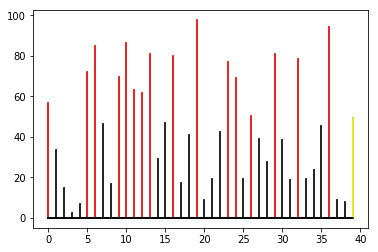

```python
import numpy as np
import include.helpers as asd1

T = np.random.uniform(0,100,40)
T[len(T)-1] = np.average(T) + 5
asd1.affiche_partition(T,0,len(T),len(T)-1)
```

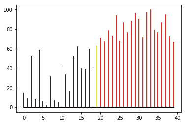

```python
i = partition(T,0,len(T))

asd1.affiche_partition(T,0,len(T),i)
```

## Algorithme récursif

### Cas trivial

un tableau de 0 ou 1 élément est déjà trié.

### Cas général

- Choisir un pivot
- Partitionner autour de ce pivot
- trier récursivement les deux côtés de la partition

```python
def tri_rapide_rec(T,premier,dernier):
    if premier < dernier-1:           # >= 2 éléments
        pivot = dernier - 1           # choix du pivot
        T[pivot],T[dernier-1] = T[dernier-1],T[pivot]

        pivot = partition(T,premier,dernier)
        afficher_partition(T,premier,pivot,dernier)

        tri_rapide_rec(T,premier,pivot)
        tri_rapide_rec(T,pivot+1,dernier)
```

```python
T = [ 7, 6, 2, 1, 3, 5, 8, 4 ]
tri_rapide_rec(T,0,len(T))
```

```
 [3, 1, 2] 4 [7, 5, 8, 6]
 [1] 2 [3]
             [5] 6 [8, 7]
                   [] 7 [8]
```

## En résumé

```python
def partition(T,premier,dernier,
              comparer = asd1.plus_petit):

    pivot = dernier-1; i = premier; j = pivot-1

    while True:
        while i < pivot    and comparer(T[i],T[pivot]): i += 1
        while j >= premier and comparer(T[pivot],T[j]): j -= 1
        if j < i: break
        asd1.echanger(T,i,j)
        i += 1; j -= 1

    asd1.echanger(T,i,pivot)
    return i
```

```python
def tri_rapide_rec(T,premier,dernier,
                   comparer = asd1.plus_petit):

    if premier < dernier-1:
        pivot = choix_du_pivot(T,premier,dernier);
        asd1.echanger(T,pivot,dernier-1)

        pivot = partition(T,premier,dernier,comparer)

        tri_rapide_rec(T,premier,pivot,comparer)
        tri_rapide_rec(T,pivot+1,dernier,comparer)
```

```python
def choix_du_pivot(T,premier,dernier):
    return dernier-1
```

```python
def tri_rapide(T,comparer = asd1.plus_petit):
    tri_rapide_rec(T,0,len(T),comparer)
```

## Visualisation

Observons les premières partition du tri de 20 entiers aléatoires entre 0 et 100

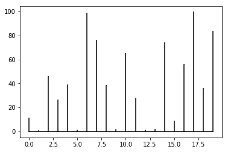

```python
import matplotlib.pyplot as plt
T = np.random.uniform(0,100,20)
plt.stem(T,markerfmt=',',linefmt='black',basefmt='black'); plt.show()
```

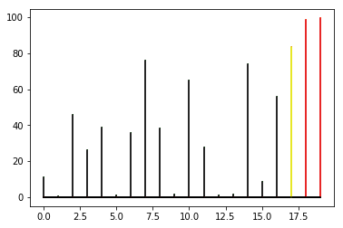

```python
p1 = partition(T,0,len(T))
asd1.affiche_partition(T,0,len(T),p1)
```

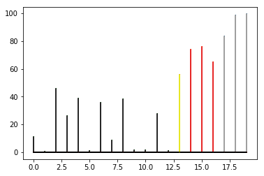

```python
p2 = partition(T,0,p1)
asd1.affiche_partition(T,0,p1,p2)
```

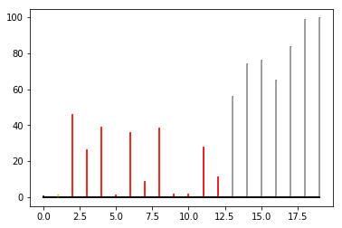

```python
p3 = partition(T,0,p2)
asd1.affiche_partition(T,0,p2,p3)
```

## Complexité

Evaluons la complexité avec une entrée aléatoire

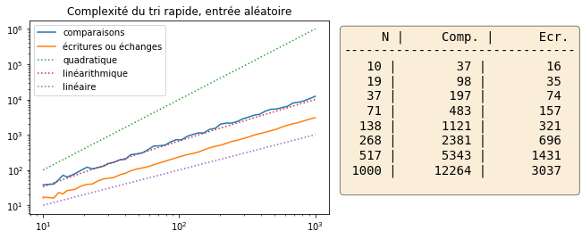

```python
asd1.evalue_complexite(tri_rapide, asd1.tableau_aleatoire,
                      "tri rapide, entrée aléatoire")
```

Nb comparaisons: $\Theta(n\log n)$. Nb échanges < Nb comparaisons

Voyons maintenant ce qui se passe avec une entrée triée

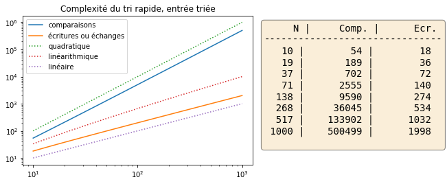

```python
asd1.evalue_complexite(tri_rapide, asd1.tableau_trie,
                       "tri rapide, entrée triée")
```

La complexité est maintenant quadratique en $\Theta(n^2)$.

Observons ce qui se passe en détail

```python
T = [ 1, 2, 3, 4, 5, 6, 7, 8]
p1 = partition(T,0,len(T)); print(T[0:p1],T[p1],T[p1+1:len(T)])
```

```
[1, 2, 3, 4, 5, 6, 7] 8 []
```

```python
p2 = partition(T,0,p1); print(T[0:p2],T[p2],T[p2+1:p1])
```

```
[1, 2, 3, 4, 5, 6] 7 []
```

```python
p3 = partition(T,0,p2); print(T[0:p3],T[p3],T[p3+1:p2])
```

```
[1, 2, 3, 4, 5] 6 []
```

```python
p4 = partition(T,0,p3); print(T[0:p4],T[p4],T[p4+1:p3])
```

```
[1, 2, 3, 4] 5 []
```

La stratégie de choix du pivot et mauvaise.

### Choix du pivot aléatoire

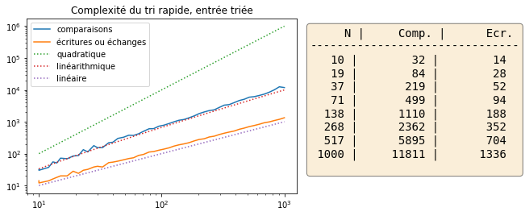

```python
def choix_du_pivot(T,premier,dernier):
    return np.random.randint(premier,dernier)

asd1.evalue_complexite(tri_rapide, asd1.tableau_trie,
                       "tri rapide, entrée triée")
```

Avec un choix aléatoire du pivot, la complexité est de nouveau linéarithmique.

### Analyse théorique

Soit $C_n$ le nombre de comparaisons nécessaires pour le tri rapide de $n$ éléments.

$C_n = (n+1) + C_k + C_{n-1-k}$

avec

- $n+1$ le nombre de comparaisons pour la partition
- $k$ le nombre d'éléments à gauche du pivot après partition
- $n-k-1$ le nombre d'éléments à droite du pivot après partition

Avec un choix de pivot aléatoire, toutes les valeurs de $k$ entre $0$ et $n-1$ sont équiprobables, de probabilité $\frac{1}{n}$.

$C_n$ vont donc en moyenne

$C_n = (n+1) + \sum_{k=0}^{n-1} \frac{1}{n}( C_k + C_{n-1-k} )$

et en notant que $\sum_{k=0}^{n-1} C_{n-1-k} = \sum_{u=0}^{n-1} C_{u}$ pour $u = n-1-k$, on obtient

$C_n = (n+1) + \frac{2}{n} \cdot \sum_{k=0}^{n-1} C_k$

Pour simplifier cette équation, notons que

$n \cdot C_n = n^2 + n + 2 \cdot \sum_{k=0}^{n-1} C_k $

$(n-1) \cdot C_{n-1} = n^2 - n + 2 \cdot \sum_{k=0}^{n-2} C_k $

En prenant la différence entre les deux, on obtient

$n \cdot C_n - (n-1) \cdot C_{n-1} = 2 \cdot n + 2 \cdot C_{n-1}$

En regroupant les termes et divisant par $n \dot (n+1)$, on trouve

$\frac{C_n}{n+1} = \frac{C_{n-1}}{n} + \frac{2}{n+1}$

en tenant compte de ce que $C_0 = C_1 = 0$ pour des tableaux de 0 ou 1 éléments, on résoud cet équation récursive ce qui donne

$C_n = 2 \cdot (n+1) \cdot \sum_{k=3}^{n+1} \frac{1}{k}$

en approximant cette somme par une intégrale, on trouve

$C_n \approx 2 \cdot (n+1) \cdot \ln n$

en logarithme népérien, ce qui donne

$C_n \approx 1.39 \cdot n \cdot \log n$

en logarithme binaire.

## Choix du pivot

Un choix aléatoire du pivot n'est évidemment pas optimal.

Le **choix optimal** serait de prendre la **valeur médiane**, qui partitionne en deux parts égales. Mais trouver cette médiane est trop cher

Un bon compromis consiste à prendre la médiane de 3 éléments

```python
def index_median(T,i1,i2,i3):
    if asd1.plus_petit(T[i1],T[i2]):
        if asd1.plus_petit(T[i2],T[i3]):    return i2
        elif asd1.plus_petit(T[i1],T[i3]):  return i3
        else:                               return i1
    else:
        if asd1.plus_petit(T[i1],T[i3]):    return i1
        elif asd1.plus_petit(T[i2],T[i3]):  return i3
        else:                               return i2
```

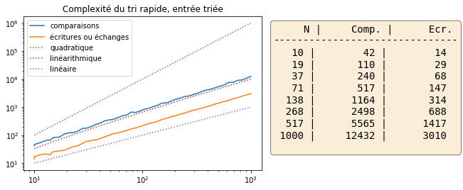

```python
def choix_du_pivot(T,premier,dernier):
    milieu = premier+(dernier-premier)//2
    return index_median(T,premier,dernier-1,milieu)

asd1.evalue_complexite(tri_rapide, asd1.tableau_aleatoire,
                       "tri rapide, entrée triée")
```

## Stabilité

Le tri rapide n'est **pas stable**.

L'opération de partition déplace les éléments selon leur comparaison avec le pivot et rien ne garantit que deux éléments égaux restent ordonnés pareillement.

```
Le tri n'est pas stable
```

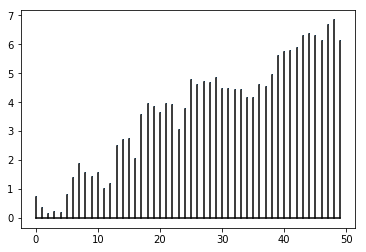

```python
asd1.test_stabilite(tri_rapide)
```

## Traitement des valeurs égales au pivot

Que se passe-t-il si le tableau contient des valeurs répétées ?

```python
def tableau_uniforme(n):
    return [1]*n

T = tableau_uniforme(10)
p1 = partition(T,0,len(T)); print(T[0:p1],T[p1],T[p1+1:len(T)])
```

```
[1, 1, 1, 1, 1] 1 [1, 1, 1, 1]
```

Les valeurs égales au pivot sont réparties dans les 2 parties

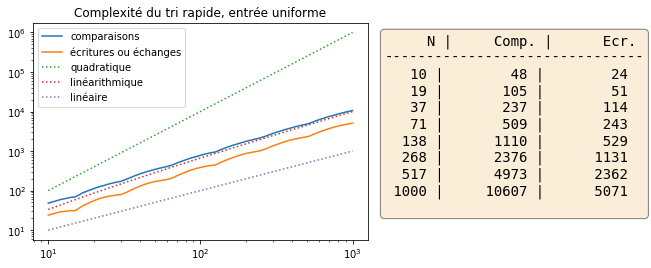

```python
asd1.evalue_complexite(tri_rapide, tableau_uniforme,
                       "tri rapide, entrée uniforme")
```

Le tri rapide reste linéarithmique en moyenne.

Mais attention ... on a fait le choix surprenant d'échanger les valeurs égales au pivot lors de la partition

i.e., on teste `T[i] < T[pivot]` et pas `T[i] <= T[pivot]` en cherchant l'indice suivant. Sinon...

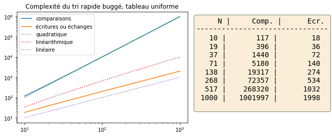

```python
def tri_rapide_bugge(T): tri_rapide(T,asd1.plus_petit_ou_egal)
asd1.evalue_complexite(tri_rapide_bugge, tableau_uniforme,
                       "tri rapide buggé, tableau uniforme")
```

Voyons ce qui se passe en détail

```python
T = tableau_uniforme(10)
p1 = partition(T,0,len(T),asd1.plus_petit_ou_egal)
print(T[0:p1],T[p1],T[p1+1:len(T)])
```

```
[1, 1, 1, 1, 1, 1, 1, 1, 1] 1 []
```

```python
p2 = partition(T,0,p1,asd1.plus_petit_ou_egal)
print(T[0:p2],T[p2],T[p2+1:p1])
```

```
[1, 1, 1, 1, 1, 1, 1, 1] 1 []
```

```python
p3 = partition(T,0,p2,asd1.plus_petit_ou_egal)
print(T[0:p3],T[p3],T[p3+1:p2])
```

```
[1, 1, 1, 1, 1, 1, 1] 1 []
```

La plupart des mises en oeuvres de `qsort` de la librairie C standard avaient ce bug jusqu'en 1991...

## Dé-récursification

Même si un bon choix de pivot le rend extrêmement improbable, le pire cas ne pose pas qu'un problème de complexité.

Si le choix du pivot ne diminue que de 1 élément la taille de la partition, le **profondeur de récursion** est de $\Theta(n)$.

Cela peut entraîner un **débordement de la pile** de récursion.

Pour éviter ce problème, on va remplacer un des 2 appels récursifs par une **boucle**

Affichons les appels effectués par le tri doublement récursif.

```python
def tri_rapide_recursif(T,premier,dernier):
    if premier < dernier-1:
        print("appel(T,{0},{1})".format(premier,dernier))
        pivot = partition(T,premier,dernier)
        afficher_partition(T,premier,pivot,dernier)
        tri_rapide_recursif(T,premier,pivot)
        tri_rapide_recursif(T,pivot+1,dernier)
```

```python
T = [ 7, 6, 4, 3, 2, 1, 8, 5 ]
tri_rapide_recursif(T,0,len(T))
```

```
appel(T,0,8)
 [1, 2, 4, 3] 5 [7, 8, 6]
appel(T,0,4)
 [1, 2] 3 [4]
appel(T,0,2)
 [1] 2 []
appel(T,5,8)
                [] 6 [8, 7]
appel(T,6,8)
                   [] 7 [8]
```

Remplaçons le **deuxième appel** par une boucle `while`

```python
def tri_rapide_semi_recursif(T,premier,dernier):
    if premier < dernier-1:
        print("appel(T,{0},{1})".format(premier,dernier))

    while premier < dernier-1:      # while remplace if
        pivot = partition(T,premier,dernier)
        afficher_partition(T,premier,pivot,dernier)
        tri_rapide_semi_recursif(T,premier,pivot)
        premier = pivot+1;          # remplace appel récursif
```

```python
T = [ 7, 6, 4, 3, 2, 1, 8, 5 ]
tri_rapide_semi_recursif(T,0,len(T))
```

```
appel(T,0,8)
 [1, 2, 4, 3] 5 [7, 8, 6]
appel(T,0,4)
 [1, 2] 3 [4]
appel(T,0,2)
 [1] 2 []
                [] 6 [8, 7]
                   [] 7 [8]
```

Mieux, choisissons **l'intervalle le plus court** pour l'appel récursif

```python
def tri_rapide_recursion_minimale(T,premier,dernier):
    if premier < dernier-1:
        print("appel(T,{0},{1})".format(premier,dernier))

    while premier < dernier-1:
        pivot = partition(T,premier,dernier)
        afficher_partition(T,premier,pivot,dernier)
        if pivot - premier < dernier - (pivot+1):
            tri_rapide_recursion_minimale(T,premier,pivot)
            premier = pivot+1;
        else:
            tri_rapide_recursion_minimale(T,pivot+1,dernier)
            dernier = pivot
```

```python
T = [ 7, 6, 4, 3, 2, 1, 8, 5 ]
tri_rapide_recursion_minimale(T,0,len(T))
```

```
appel(T,0,8)
 [1, 2, 4, 3] 5 [7, 8, 6]
appel(T,5,8)
                [] 6 [8, 7]
                   [] 7 [8]
 [1, 2] 3 [4]
 [1] 2 []
```

En remplaçant l'appel récursif pour l'intervalle le plus long par une boucle,

la taille de l'intervalle pour l'appel récursif est au moins divisée par 2 à chaque appel

la **profondeur de récursion** est au plus de $\mathcal{O}(\log(n))$

## Complexité spatiale

La **partition** s'effectue en place. Elle n'utilise qu'un nombre constant de variables auxilliaires

- les compteurs `i` et `j`
- une variable temporaire pour les échanges

La complexité spatiale de la partition est donc $\Theta(1)$.

Mais ...

Le tri rapide est un **algorithme récursif**, et chaque appel récursif nécessite de la mémoire pour

- la pile d'appels
- les variables locales

La complexité spatiale du tri rapide est donc **proportionelle à la profondeur de récursion maximale**.

- $\Theta(\log(n))$ en moyenne et $\Theta(n)$ au pire pour la version doublement récursive
- $\Theta(\log(n))$ au pire pour la version remplaçant une récursion par une boucle

## Conclusion

Le tri rapide

- n'est pas stable
- a une complexité temporelle moyenne en $\Theta(n\log(n))$
- a une complexité temporelle en $\Theta(n^2)$ dans le pire des cas
  - peu probable avec un bon choix de pivot
  - très probable (entrée triée) avec un mauvais choix
- a une complexité spatiale en $\Theta(\log(n))$ quand il est bien mis en oeuvre
- est plus rapide que le tri fusion en pratique (moins d'écritures, meilleure utilisation de la mémoire cache)

|  | [ASD1 Notebooks on GitHub.io](https://ocuisenaire.github.io/ASD1-notebooks/) © Olivier Cuisenaire, 2018 |
| --- | --- |